# DACSS 603 Homework 2

Homework 2

Kirsten Johnson  
3/27/2022

### Questions 1

###### (Problem 1.1 in ALR)

##### United Nations (Data file: UN11) The data in the file UN11 contains several variables, including ppgdp, the gross national product per person in U.S. dollars, and fertility, the birth rate per 1000 females, both from the year 2009. The data are for 199 localities, mostly UN member countries, but also other areas such as Hong Kong that are not independent countries. The data were collected from the United Nations (2011). We will study the dependence of fertility on ppgdp.

Let’s load and preview the UN11 data set first. Since we’re only interested in ppgdp and fertility, I’ll filter out the variables that I don’t need.

```r
### Load United Nations data
data("UN11")
### Filter and preview data for ppgdp and fertility
UN11<- UN11 %>%
  select(c(ppgdp, fertility))
head(UN11)
```

```
              ppgdp fertility
Afghanistan   499.0     5.968
Albania      3677.2     1.525
Algeria      4473.0     2.142
Angola       4321.9     5.135
Anguilla    13750.1     2.000
Argentina    9162.1     2.172
```

##### 1.1.1. Identify the predictor and the response.

Since we are wondering about the dependence of fertility on ppgdp, the predictor or the independent variable is ppgdp and the response or the independent variable is fertility.

##### 1.1.2 Draw the scatterplot of fertility on the vertical axis versus ppgdp on the horizontal axis and summarize the information in this graph. Does a straight-line mean function seem to be plausible for a summary of this graph?

I’ll use the plot function to create a scatterplot of ppgdp vs fertility.

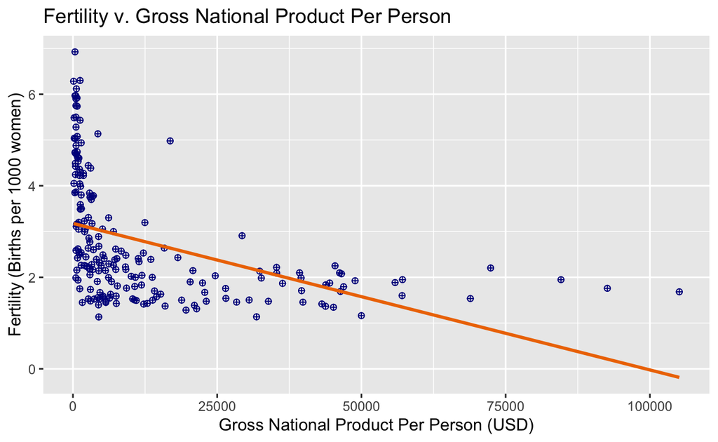

```r
### Draw scatterplot of ppgdp and fertility
ggplot(UN11, aes(x=ppgdp, y=fertility)) +
  geom_point(shape=10, color="darkblue")+
  geom_smooth(method=lm, se=FALSE, color="darkorange2")+
  labs(title = "Fertility v. Gross National Product Per Person", x = "Gross National Product Per Person (USD)", y = "Fertility (Births per 1000 women)")
```

A scatter plot doesn’t seem like a plausible summary of this graph. As ppgdp decreases, fertility has more values but doesn’t appear have a consistent response or pattern. The straight line mean function doesn’t summarize the data in a way to determine if/what the relationship is between the variables or if there is a clear dependence of the response on the predictor.

##### 1.1.3 Draw the scatterplot of log(fertility) versus log(ppgdp) using natural logarithms. Does the simple linear regression model seem plausible for a summary of this graph? If you use a different base of logarithms, the shape of the graph won’t change, but the values on the axes will change.

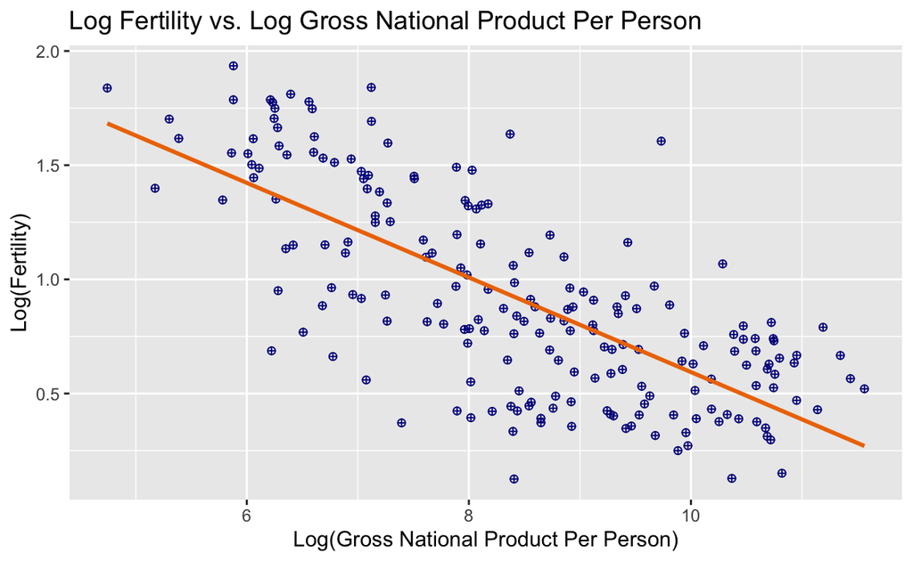

```r
### Draw scatterplot of log(ppgdp) and log(fertility)
ggplot(UN11, aes(x=log(ppgdp), y=log(fertility))) +
  geom_point(shape=10, color="darkblue")+
  geom_smooth(method=lm, se=FALSE, color="darkorange2")+
  labs(title = "Log Fertility vs. Log Gross National Product Per Person", x = "Log(Gross National Product Per Person)", y = "Log(Fertility)")
```

A simple linear regression model using the natural log of the variables looks to be a much better fit to show the dependencey fertility on ppgdp. We can clearly see that as ppgdp increases, fertility decreases.

### Question 2

###### (Problem 9.47 in SMSS)

##### Annual income, in dollars, is an explanatory variable in a regression analysis. For a British version of the report on the analysis, all responses are converted to British pounds sterling (1 pound equals about 1.33 dollars, as of 2016).

##### (a) How, if at all, does the slope of the prediction equation change?

##### (b) How, if at all, does the correlation change?

To illustrate, I will create an imaginary scenario where annual income predicts the size of someone’s residence.I will create columns for income in USD, income in pounds, and residence size in square feet.

```r
usd=c(279900, 146500, 237700, 200000, 289900)
pounds=round(usd/1.33)
size= c(2048, 912, 1654, 2068,2075)
```

```r
### Generate data of income in USD, income in pounds and residence size in square feet
id= c(1,2,3,4,5)
usd=c(27990, 14650, 23770, 20000, 28990)
pounds=round(usd/1.33)
size= c(2048, 912, 1654, 2068,2075)
df<-data.frame(id,usd,pounds,size)
### View data
df
```

```
  id   usd pounds size
1  1 27990  21045 2048
2  2 14650  11015  912
3  3 23770  17872 1654
4  4 20000  15038 2068
5  5 28990  21797 2075
```

Now that we have some data, I will use the lm function to fit the data to a linear model where income is the explanatory variable and size is the response variable. I will create separate models for income in pounds and USD.

```r
### fit data to linear model for residence size vs income in USD
usdsizefit<-lm(size~usd, data = df)
summary(usdsizefit)
```

```
Call:
lm(formula = size ~ usd, data = df)

Residuals:
      1       2       3       4       5
 -33.01 -273.49 -143.72  523.36  -73.14

Coefficients:
             Estimate Std. Error t value Pr(>|t|)
(Intercept) 202.01974  708.14080   0.285    0.794
usd           0.06713    0.02991   2.245    0.110

Residual standard error: 353.9 on 3 degrees of freedom
Multiple R-squared:  0.6268,    Adjusted R-squared:  0.5024
F-statistic: 5.039 on 1 and 3 DF,  p-value: 0.1105
```

```r
### fit data to linear model for residence size vs income in pounds
poundssizefit<-lm(size~pounds, data = df)
summary(poundssizefit)
```

```
Call:
lm(formula = size ~ pounds, data = df)

Residuals:
      1       2       3       4       5
 -33.02 -273.45 -143.71  523.34  -73.16

Coefficients:
             Estimate Std. Error t value Pr(>|t|)
(Intercept) 201.94000  708.10907   0.285    0.794
pounds        0.08929    0.03977   2.245    0.110

Residual standard error: 353.9 on 3 degrees of freedom
Multiple R-squared:  0.6269,    Adjusted R-squared:  0.5025
F-statistic:  5.04 on 1 and 3 DF,  p-value: 0.1105
```

In the USD example, the slope estimate is 0.067. In the pounds example, the slope is 0.089. Since the units of pounds are smaller, as the units get smaller of the explanatory variable, the slope increases. This makes sense since slope can be calculated as y/x. If the units of x get smaller, the slope will increase since the denominator is decreasing. This proves that slope can change if the units of the variables change.

The r^2 for both examples are extremely close, only different by 0.0001, this is likely because I rounded the conversion from USD to pounds. For our purposes, the r^2 are the same. This makes since because r^2 is a standardized measure of fit and cannot be impacted by units. If the units of a variable change, their relationship with other variables will not change.

### Question 3

###### (Problem 1.5 in ALR)

##### Water runoff in the Sierras (Data file: water) Can Southern California’s water supply in future years be predicted from past data? One factor affecting water availability is stream runoff. If runoff could be predicted, engineers, planners, and policy makers could do their jobs more efficiently. The data file contains 43 years’ worth of precipitation measurements taken at six sites in the Sierra Nevada mountains (labeled APMAM, APSAB, APSLAKE, OPBPC, OPRC, and OPSLAKE) and stream runoff volume at a site near Bishop, California, labeled BSAAM. Draw the scatterplot matrix for these data and summarize the information available from these plots.

First, I will load and preview the data.

```r
### Load water dataset
data("water")
### Preview runoff data
head(water)
```

```
  Year APMAM APSAB APSLAKE OPBPC  OPRC OPSLAKE  BSAAM
1 1948  9.13  3.58    3.91  4.10  7.43    6.47  54235
2 1949  5.28  4.82    5.20  7.55 11.11   10.26  67567
3 1950  4.20  3.77    3.67  9.52 12.20   11.35  66161
4 1951  4.60  4.46    3.93 11.14 15.15   11.13  68094
5 1952  7.15  4.99    4.88 16.34 20.05   22.81 107080
6 1953  9.70  5.65    4.91  8.88  8.15    7.41  67594
```

For this data, the precipitation at each site are the predictors and the runoff (BSAAM) is the response. Next I’ll generate the scatter plot matrix for the data.

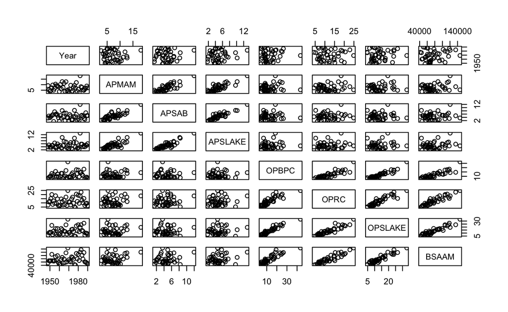

```r
### Generate scatterplot matrix
pairs(water)
```

Some of the key findings from these scatter plots are:

1. There looks to be positive correlation between APMAM, APSAB and APSLAKE. Any combination of those sites seems to have a positive correlation between their precipitation measurements.
2. Similarly to #1, OPBPC, OPRC, OPSLAKE all look to be positively correlated. My guess is that these sites are nearby each other as are the sites from #1.
3. Stream runoff volume, BSAAM, looks to be positively correlated with OPBPC, OPRC, and OPSLAKE.
4. Year does not look to have a strong correlation with any of the variables.

### Question 4

###### (Problem 1.6 in ALR - slightly modified)

##### Professor ratings (Data file: Rateprof) In the website and online forum RateMyProfessors.com, students rate and comment on their instructors. Launched in 1999, the site includes millions of ratings on thousands of instructors. The data file includes the summaries of the ratings of 364 instructors at a large campus in the Midwest (Bleske-Rechek and Fritsch, 2011). Each instructor included in the data had at least 10 ratings over a several year period. Students provided ratings of 1–5 on quality, helpfulness, clarity, easiness of instructor’s courses, and raterInterest in the subject matter covered in the instructor’s courses. The data file provides the averages of these five ratings. Use R to reproduce the scatterplot matrix in Figure 1.13 in the ALR book (page 20). Provide a brief description of the relationships between the five ratings. (The variables don’t have to be in the same order)

First, I will import the data, filter the variables to only include quality, helpfulness, clarity, easiness of instructor’s courses, and raterInterest, and preview the data.

```r
data("Rateprof")
rateprof<- Rateprof
rateprofselect<-rateprof%>%
  select(quality, helpfulness, clarity, easiness, "raterInterest")
head(rateprofselect)
```

```
   quality helpfulness  clarity easiness raterInterest
1 4.636364    4.636364 4.636364 4.818182      3.545455
2 4.318182    4.545455 4.090909 4.363636      4.000000
3 4.790698    4.720930 4.860465 4.604651      3.432432
4 4.250000    4.458333 4.041667 2.791667      3.181818
5 4.684211    4.684211 4.684211 4.473684      4.214286
6 4.233333    4.266667 4.200000 4.533333      3.916667
```

Now that I have the variables I need, I’ll create the scatterplot matrix.

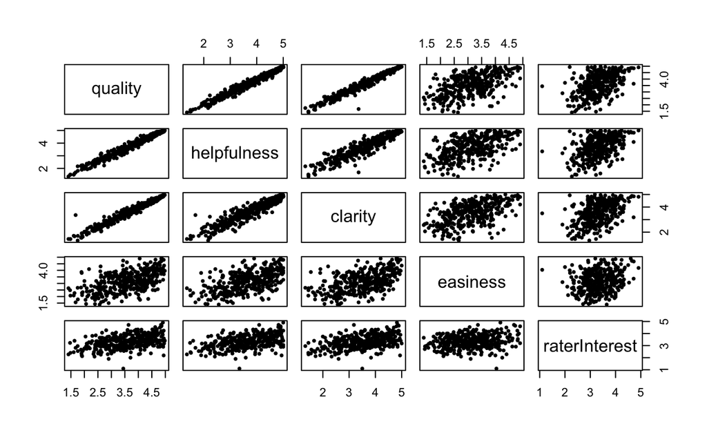

```r
pairs(rateprofselect, pch = 19,  cex = 0.5,
      col = "black")
```

Here are some thoughts about the relationships between the ratings:

1. Quality vs. helpfulness, quality vs. clarity, and clarity vs. helpfulness all have very strong, positive correlations. Given that these ratings are all very closely related in terms of what makes a good course, it isn’t surprising that these variables show a clear dependency. These ratings have much weaker relationships with easiness and raterInterest.
2. Interestingly, raterInterest has a very gentle positive slope against the other ratings, and to me it looks like the slope would be closer to zero across all of the other ratings. This shows that the rater’s interest in the subject matter doesn’t seem to be very dependent on the quality, helpfulness, clarity, or easiness of the course.
3. Easiness has a positive relationship with clarity, helpfulness, and quality, but the relationship isn’t as strong as the ratings from #1. There is much more variability in the ratings. There doesn’t seem to be strong dependency of course easiness and raterInterst.

### Question 5

###### (Problem 9.34 in SMSS)

##### For the student.survey data file in the smss package, conduct regression analyses relating

##### (i) y = political ideology and x = religiosity,

##### (ii) y = high school GPA and x = hours of TV watching.

##### (a) Use graphical ways to portray the individual variables and their relationship.

I will load the student survey data, select my variables of interest and get a summary of the data.

```r
### Load student survey data, select and preview variables for political ideology, religiosity, high school gpa and hours of TV watching
data("student.survey")
studentsurvey<- student.survey%>%
  select(pi, re, hi, tv)
head(studentsurvey)
```

```
            pi           re  hi tv
1 conservative   most weeks 2.2  3
2      liberal occasionally 2.1 15
3      liberal   most weeks 3.3  0
4     moderate occasionally 3.5  5
5 very liberal        never 3.1  6
6      liberal occasionally 3.5  4
```

Since political ideology and religiosity are catagorical variables, I will create different visualizations from high schoolGPA and hours of TV watching, as those are numerical variables.

For political ideology vs. religiosity I will create a stacked bar chart.

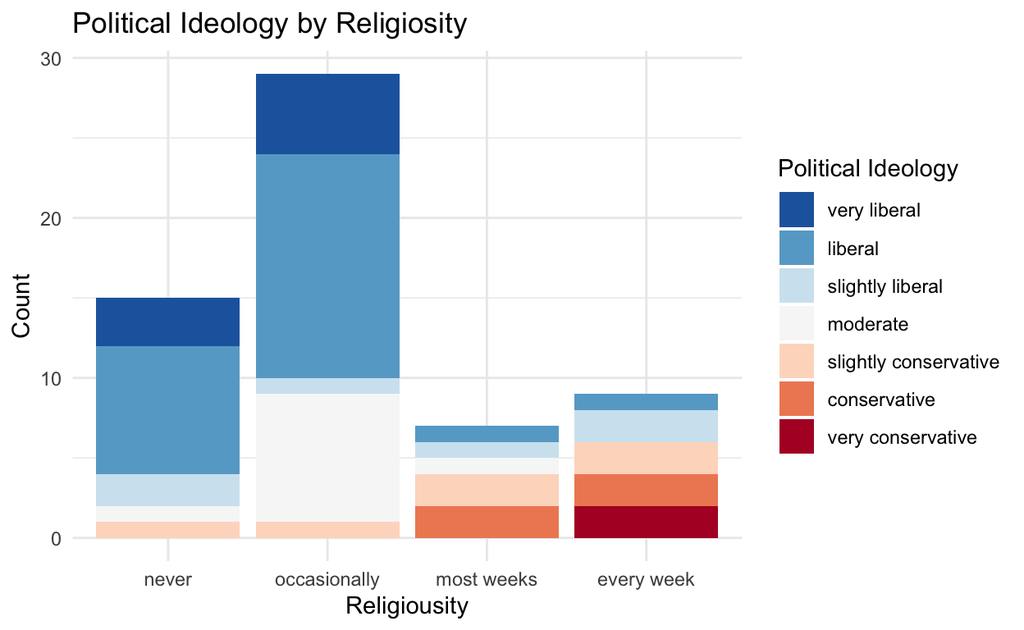

```r
ggplot(studentsurvey,
       aes(x = factor(re,
                      levels = c("never", "occasionally",
                                 "most weeks", "every week")),
           fill = factor(pi,
                         levels = c("very liberal", "liberal", "slightly liberal",
                                    "moderate","slightly conservative",
                                    "conservative","very conservative"),
                         labels = c("very liberal", "liberal", "slightly liberal",
                                    "moderate","slightly conservative",
                                    "conservative","very conservative")))) +

  geom_bar(position = "stack") +
  scale_fill_brewer(palette = "RdBu", direction= -1) +
  labs(y = "Count",
       fill = "Political Ideology",
       x = "Religiousity",
       title = "Political Ideology by Religiosity") +
  theme_minimal()
```

This stacked bar chart shows that as graduate student responses leaning more liberal increase, frequency attending religious services decreases. As graduate students who identify as conservative responses become more conservative, there are more response to attending religious services more frequently.

I will create a scatterplot for high school GPA vs hours of TV watching.

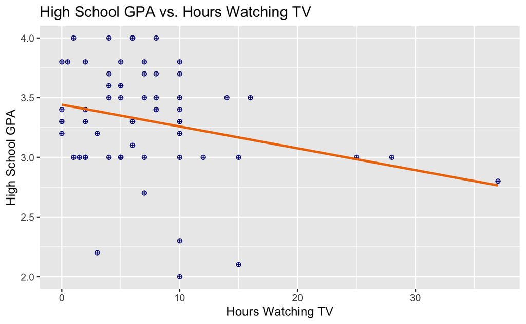

```r
# scatterplot with linear fit line
ggplot(studentsurvey,
       aes(x = tv,
           y = hi)) +
  geom_point(shape=10, color="darkblue")+
  geom_smooth(method=lm, se=FALSE, color="darkorange2")+
  labs(title = "High School GPA vs. Hours Watching TV", x= "Hours Watching TV", y = "High School GPA")
```

High school GPA has a negative relationship with hours watching TV.

##### (b) Interpret descriptive statistics for summarizing the individual variables and their relationship.

I will use the summary function to get descriptive statistics.

```r
summary(studentsurvey)
```

```
                     pi                re           hi
 very liberal         : 8   never       :15   Min.   :2.000
 liberal              :24   occasionally:29   1st Qu.:3.000
 slightly liberal     : 6   most weeks  : 7   Median :3.350
 moderate             :10   every week  : 9   Mean   :3.308
 slightly conservative: 6                     3rd Qu.:3.625
 conservative         : 4                     Max.   :4.000
 very conservative    : 2
       tv
 Min.   : 0.000
 1st Qu.: 3.000
 Median : 6.000
 Mean   : 7.267
 3rd Qu.:10.000
 Max.   :37.000
```

Political ideology and religiosity summaries show the number of responses for each category.There is variability in the number of response for each category. For political ideology, there are significantly more responses for the liberal categories versus the conservative. This could mean the graduate school where the survey was taken is in a more liberal location. As a result, there are also more responses for less religiosity. There may be some bias in the sample.

For the high school GPA and hours watching TV, we are given numerical summaries. For high school GPA, there is a specific scale, so the quartile values seem reasonable. The hours of TV summary has much more variability, as the max has a huge value that differs significantly from the mean. The presence of these outliners may mean the tv hours data is skewed.

##### (c) Summarize and interpret results of inferential analyses.

I will conduct a correlation test for each of the variable pairs. The political ideology and religiosity variables are categorical, we will need to assume that they are correlated and treat them as numeric.

```r
### Conduct regression test for pi vs re
cor.test(as.numeric(studentsurvey$pi), as.numeric(studentsurvey$re))
```

```
    Pearson's product-moment correlation

data:  as.numeric(studentsurvey$pi) and as.numeric(studentsurvey$re)
t = 5.4163, df = 58, p-value = 1.221e-06
alternative hypothesis: true correlation is not equal to 0
95 percent confidence interval:
 0.3818345 0.7265650
sample estimates:
      cor
0.5795661
```

Our p value is less than 0.05, making the correlation statistically significant between political ideology and religiosity. We can reject the null hypothesis in favor of the alternative hypothesis that true correlation is not equal to zero. The test also returned a positive correlation estimate, meaning they are positively correlated.

Let’s do the same for GPA and TV hours.

```r
### Conduct regression test for hi vs tv
cor.test(studentsurvey$hi, studentsurvey$tv)
```

```
    Pearson's product-moment correlation

data:  studentsurvey$hi and studentsurvey$tv
t = -2.1144, df = 58, p-value = 0.03879
alternative hypothesis: true correlation is not equal to 0
95 percent confidence interval:
 -0.48826914 -0.01457694
sample estimates:
       cor
-0.2675115
```

We have another p-value less than 0.05, making the correlation statistically significant between high school GPA and hours watching TV. We can reject the null hypothesis in favor of the alternative hypothesis that true correlation is not equal to zero. This time, the test returned a negative correlation estimate, meaning the variables are negatively correlated, which we saw in our previous graphics.

### Question 6

###### (Problem 9.50 in SMSS)

##### For a class of 100 students, the teacher takes the 10 students who perform poorest on the midterm exam and enrolls them in a special tutoring program. The overall class mean is 70 on both the midterm and final, but the mean for the specially tutored students increases from 50 to 60. Use the concept of regression toward the mean to explain why this is not sufficient evidence to imply that the tutoring program was successful. (Here’s a useful hint video: https://www.youtube.com/watch?v=1tSqSMOyNFE)

There is an element of chance to take into consideration when observing these scores. Some of the initial test takers may have scored a certain way due to skill, but some of the more extreme scores may have scored a certain way just due to chance. There is inherent variability in the sample outside of someone’s knowledge of the test material. When taking the mean of specifically the tutored students, the odds subset of students doing better on their second try are higher since these students were outliers during the first try. It makes sense that their second try is closer to the mean, since its like taking a new sample. The improvement in the tutored students could be due to their scores regressing towards the mean and not just based on the tutoring program.